# INFM600_0201_TeamExceptional_RScript

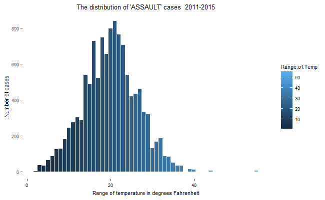

```r
#ASSAULT
ggplot(data=rangeT_assault, aes(x=Range.of.Temp, y=NumberofCases, fill=Range.of.Temp)) +
  geom_bar(stat="identity")+
  labs(title = "The distribution of 'ASSAULT' cases  2011-2015", x="Range of temperature in degrees Fahrenheit", y="Number of cases")+
  theme_xkcd+
  theme(plot.title = element_text(hjust = 0.5))
```

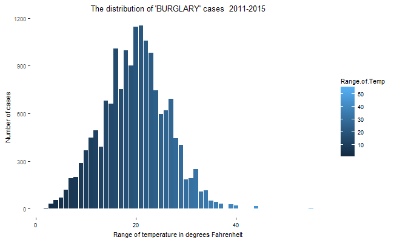

```r
#BURGLARY
ggplot(data=rangeT_burglary, aes(x=Range.of.Temp, y=NumberofCases, fill=Range.of.Temp)) +
  geom_bar(stat="identity")+
  labs(title = "The distribution of 'BURGLARY' cases  2011-2015", x="Range of temperature in degrees Fahrenheit", y="Number of cases")+
  theme_xkcd+
  theme(plot.title = element_text(hjust = 0.5))
```

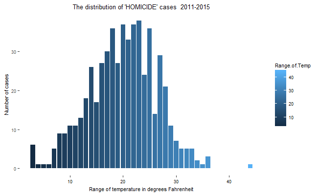

```r
#HOMICIDE
ggplot(data=rangeT_homicide, aes(x=Range.of.Temp, y=NumberofCases, fill=Range.of.Temp)) +
  geom_bar(stat="identity")+
  labs(title = "The distribution of 'HOMICIDE' cases  2011-2015", x="Range of temperature in degrees Fahrenheit", y="Number of cases")+
  theme_xkcd+
  theme(plot.title = element_text(hjust = 0.5))
```

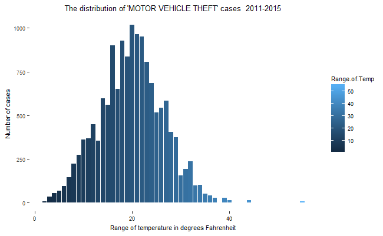

```r
#MOTOR VEHICLE THEFT
ggplot(data=rangeT_mvt, aes(x=Range.of.Temp, y=NumberofCases, fill=Range.of.Temp)) +
  geom_bar(stat="identity")+
  labs(title = "The distribution of 'MOTOR VEHICLE THEFT' cases  2011-2015", x="Range of temperature in degrees Fahrenheit", y="Number of cases")+
  theme_xkcd+
  theme(plot.title = element_text(hjust = 0.5))
```

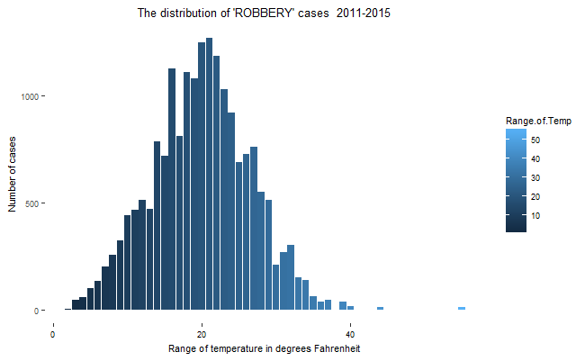

```r
#ROBBERY
ggplot(data=rangeT_robbery, aes(x=Range.of.Temp, y=NumberofCases, fill=Range.of.Temp)) +
  geom_bar(stat="identity")+
  labs(title = "The distribution of 'ROBBERY' cases  2011-2015", x="Range of temperature in degrees Fahrenheit", y="Number of cases")+
  theme_xkcd+
  theme(plot.title = element_text(hjust = 0.5))
```

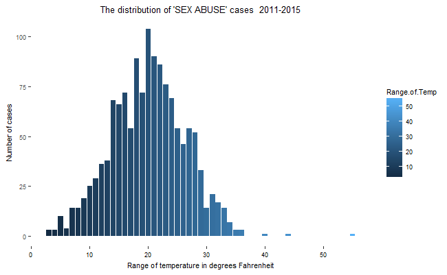

```r
#SEX ABUSE
ggplot(data=rangeT_sa, aes(x=Range.of.Temp, y=NumberofCases, fill=Range.of.Temp)) +
  geom_bar(stat="identity")+
  labs(title = "The distribution of 'SEX ABUSE' cases  2011-2015", x="Range of temperature in degrees Fahrenheit", y="Number of cases")+
  theme_xkcd+
  theme(plot.title = element_text(hjust = 0.5))
```

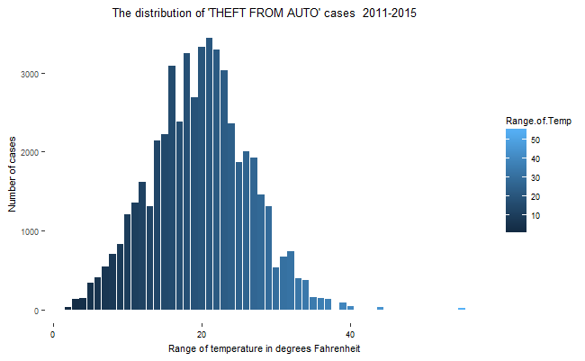

```r
#THEFT FROM AUTO
ggplot(data=rangeT_thefa, aes(x=Range.of.Temp, y=NumberofCases, fill=Range.of.Temp)) +
  geom_bar(stat="identity")+
  labs(title = "The distribution of 'THEFT FROM AUTO' cases  2011-2015", x="Range of temperature in degrees Fahrenheit", y="Number of cases")+
  theme_xkcd+
  theme(plot.title = element_text(hjust = 0.5))
```

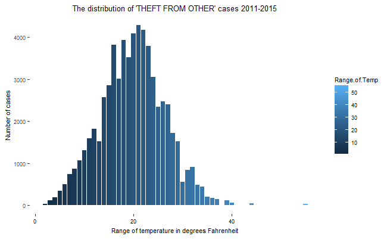

```r
#THEFT FROM OTHER
ggplot(data=rangeT_thefot, aes(x=Range.of.Temp, y=NumberofCases, fill=Range.of.Temp)) +
  geom_bar(stat="identity")+
  labs(title = "The distribution of 'THEFT FROM OTHER' cases 2011-2015", x="Range of temperature in degrees Fahrenheit", y="Number of cases")+
  theme_xkcd+
  theme(plot.title = element_text(hjust = 0.5))
```

Part 3: Compare the impact of max temperature on the occurrence rate of all types of cases. Find the frequency of each type of cases from the data of 2011-2015 corresponding to each numerical value in “max temperature” column. Independent varibale: Max Temprature of each day from 2011 to 2015 (interval) Dependent varibale: The frequency of each type of cases happened (ratio)

```r
#ARSON
# [Step 1] Finding out the max temperature on the day when this type of cases happened, and then counting the frequency of the same type of cases corresponding to each temperature.
maxT_arson=table(arson$MaxTemp)
maxT_arson=as.data.frame(maxT_arson)
# [Step 2] Saving the value of temperature and  frequency of the type of cases in a new data frame
maxT_arson$Var1=as.numeric(as.character(maxT_arson$Var1))
# [Step 3] Renaming columns' names
maxT_arson=rename(maxT_arson, c("Var1"="MaxTemp", "Freq"="NumberofCases"))
#ASSAULT
# [Step 1] Finding out the max temperature on the day when this type of cases happened, and then counting the frequency of the same type of cases corresponding to each temperature.
maxT_assault=table(assault$MaxTemp)
maxT_assault=as.data.frame(maxT_assault)
# [Step 2] Saving the value of temperature and  frequency of the type of cases in a new data frame
maxT_assault$Var1=as.numeric(as.character(maxT_assault$Var1))
# [Step 3] Renaming columns' names
maxT_assault=rename(maxT_assault, c("Var1"="MaxTemp", "Freq"="NumberofCases"))
#BURGLARY
# [Step 1] Finding out the max temperature on the day when this type of cases happened, and then counting the frequency of the same type of cases corresponding to each temperature.
maxT_burglary=table(burglary$MaxTemp)
maxT_burglary=as.data.frame(maxT_burglary)
# [Step 2] Saving the value of temperature and  frequency of the type of cases in a new data frame
maxT_burglary$Var1=as.numeric(as.character(maxT_burglary$Var1))
# [Step 3] Renaming columns' names
maxT_burglary=rename(maxT_burglary, c("Var1"="MaxTemp", "Freq"="NumberofCases"))
#HOMICIDE
# [Step 1] Finding out the max temperature on the day when this type of cases happened, and then counting the frequency of the same type of cases corresponding to each temperature.
maxT_homicide=table(homicide$MaxTemp)
maxT_homicide=as.data.frame(maxT_homicide)
# [Step 2] Saving the value of temperature and  frequency of the type of cases in a new data frame
maxT_homicide$Var1=as.numeric(as.character(maxT_homicide$Var1))
# [Step 3] Renaming columns' names
maxT_homicide=rename(maxT_homicide, c("Var1"="MaxTemp", "Freq"="NumberofCases"))
#MOTOR VEHICLE THEFT
# [Step 1] Finding out the max temperature on the day when this type of cases happened, and then counting the frequency of the same type of cases corresponding to each temperature.
maxT_mvt=table(mvt$MaxTemp)
maxT_mvt=as.data.frame(maxT_mvt)
# [Step 2] Saving the value of temperature and  frequency of the type of cases in a new data frame
maxT_mvt$Var1=as.numeric(as.character(maxT_mvt$Var1))
# [Step 3] Renaming columns' names
maxT_mvt=rename(maxT_mvt, c("Var1"="MaxTemp", "Freq"="NumberofCases"))
#ROBBERY
# [Step 1] Finding out the max temperature on the day when this type of cases happened, and then counting the frequency of the same type of cases corresponding to each temperature.
maxT_robbery=table(robbery$MaxTemp)
maxT_robbery=as.data.frame(maxT_robbery)
# [Step 2] Saving the value of temperature and  frequency of the type of cases in a new data frame
maxT_robbery$Var1=as.numeric(as.character(maxT_robbery$Var1))
# [Step 3] Renaming columns' names
maxT_robbery=rename(maxT_robbery, c("Var1"="MaxTemp", "Freq"="NumberofCases"))
#SEX ABUSE
# [Step 1] Finding out the max temperature on the day when this type of cases happened, and then counting the frequency of the same type of cases corresponding to each temperature.
maxT_sa=table(sa$MaxTemp)
maxT_sa=as.data.frame(maxT_sa)
# [Step 2] Saving the value of temperature and  frequency of the type of cases in a new data frame
maxT_sa$Var1=as.numeric(as.character(maxT_sa$Var1))
# [Step 3] Renaming columns' names
maxT_sa=rename(maxT_sa, c("Var1"="MaxTemp", "Freq"="NumberofCases"))
#THEFT FROM AUTO
# [Step 1] Finding out the max temperature on the day when this type of cases happened, and then counting the frequency of the same type of cases corresponding to each temperature.
maxT_thefa=table(thefa$MaxTemp)
maxT_thefa=as.data.frame(maxT_thefa)
# [Step 2] Saving the value of temperature and  frequency of the type of cases in a new data frame
maxT_thefa$Var1=as.numeric(as.character(maxT_thefa$Var1))
# [Step 3] Renaming columns' names
maxT_thefa=rename(maxT_thefa, c("Var1"="MaxTemp", "Freq"="NumberofCases"))
#THEFT FROM OTHER
# [Step 1] Finding out the max temperature on the day when this type of cases happened, and then counting the frequency of the same type of cases corresponding to each temperature.
maxT_thefot=table(thefot$MaxTemp)
maxT_thefot=as.data.frame(maxT_thefot)
# [Step 2] Saving the value of temperature and  frequency of the type of cases in a new data frame
maxT_thefot$Var1=as.numeric(as.character(maxT_thefot$Var1))
# [Step 3] Renaming columns' names
maxT_thefot=rename(maxT_thefot, c("Var1"="MaxTemp", "Freq"="NumberofCases"))
# Part 4: Using "simple linear regression model" to analyze the relationship between IV and DV,because IV is interval,and DV is ratio.
#ARSON
summary(lm(NumberofCases~MaxTemp,data=maxT_arson))
```

```
Call:
lm(formula = NumberofCases ~ MaxTemp, data = maxT_arson)

Residuals:
    Min      1Q  Median      3Q     Max
-2.4923 -1.1058 -0.3112  0.5789  5.4934

Coefficients:
            Estimate Std. Error t value Pr(>|t|)
(Intercept)  1.42040    0.81078   1.752   0.0855 .
MaxTemp      0.02012    0.01147   1.754   0.0850 .
---
Signif. codes:  0 â€˜***â€™ 0.001 â€˜**â€™ 0.01 â€˜*â€™ 0.05 â€˜.â€™ 0.1 â€˜ â€™ 1

Residual standard error: 1.702 on 54 degrees of freedom
Multiple R-squared:  0.05393,   Adjusted R-squared:  0.03641
F-statistic: 3.078 on 1 and 54 DF,  p-value: 0.08503
```

```r
#ASSAULT
summary(lm(NumberofCases~MaxTemp,data=maxT_assault))
```

```
Call:
lm(formula = NumberofCases ~ MaxTemp, data = maxT_assault)

Residuals:
    Min      1Q  Median      3Q     Max
-198.12  -53.84   12.54   48.36  212.19

Coefficients:
            Estimate Std. Error t value Pr(>|t|)
(Intercept)  24.9851    24.4034   1.024    0.309
MaxTemp       1.7538     0.3637   4.822    6e-06 ***
---
Signif. codes:  0 â€˜***â€™ 0.001 â€˜**â€™ 0.01 â€˜*â€™ 0.05 â€˜.â€™ 0.1 â€˜ â€™ 1

Residual standard error: 88.71 on 87 degrees of freedom
Multiple R-squared:  0.2109,    Adjusted R-squared:  0.2018
F-statistic: 23.25 on 1 and 87 DF,  p-value: 6.003e-06
```

```r
#BURGLARY
summary(lm(NumberofCases~MaxTemp,data=maxT_burglary))
```

```
Call:
lm(formula = NumberofCases ~ MaxTemp, data = maxT_burglary)

Residuals:
    Min      1Q  Median      3Q     Max
-278.71  -82.02   19.55   83.11  229.04

Coefficients:
            Estimate Std. Error t value Pr(>|t|)
(Intercept)   40.908     33.343   1.227    0.223
MaxTemp        2.338      0.497   4.704 9.53e-06 ***
---
Signif. codes:  0 â€˜***â€™ 0.001 â€˜**â€™ 0.01 â€˜*â€™ 0.05 â€˜.â€™ 0.1 â€˜ â€™ 1

Residual standard error: 121.2 on 87 degrees of freedom
Multiple R-squared:  0.2028,    Adjusted R-squared:  0.1936
F-statistic: 22.13 on 1 and 87 DF,  p-value: 9.531e-06
```

```r
#HOMICIDE
summary(lm(NumberofCases~MaxTemp,data=maxT_homicide))
```

```
Call:
lm(formula = NumberofCases ~ MaxTemp, data = maxT_homicide)

Residuals:
    Min      1Q  Median      3Q     Max
-10.188  -2.321  -0.570   2.521  16.420

Coefficients:
            Estimate Std. Error t value Pr(>|t|)
(Intercept)   0.7546     1.4742   0.512     0.61
MaxTemp       0.1003     0.0220   4.560  1.9e-05 ***
---
Signif. codes:  0 â€˜***â€™ 0.001 â€˜**â€™ 0.01 â€˜*â€™ 0.05 â€˜.â€™ 0.1 â€˜ â€™ 1

Residual standard error: 4.592 on 77 degrees of freedom
Multiple R-squared:  0.2126,    Adjusted R-squared:  0.2024
F-statistic: 20.79 on 1 and 77 DF,  p-value: 1.897e-05
```

```r
#MOTOR VEHICLE THEFT
summary(lm(NumberofCases~MaxTemp,data=maxT_mvt))
```

```
Call:
lm(formula = NumberofCases ~ MaxTemp, data = maxT_mvt)

Residuals:
    Min      1Q  Median      3Q     Max
-242.54  -67.03   13.42   69.02  226.35

Coefficients:
            Estimate Std. Error t value Pr(>|t|)
(Intercept)  38.5968    29.0160   1.330    0.187
MaxTemp       2.0466     0.4325   4.732 8.53e-06 ***
---
Signif. codes:  0 â€˜***â€™ 0.001 â€˜**â€™ 0.01 â€˜*â€™ 0.05 â€˜.â€™ 0.1 â€˜ â€™ 1

Residual standard error: 105.5 on 87 degrees of freedom
Multiple R-squared:  0.2047,    Adjusted R-squared:  0.1956
F-statistic: 22.39 on 1 and 87 DF,  p-value: 8.532e-06
```

```r
#ROBBERY
summary(lm(NumberofCases~MaxTemp,data=maxT_robbery))
```

```
Call:
lm(formula = NumberofCases ~ MaxTemp, data = maxT_robbery)

Residuals:
    Min      1Q  Median      3Q     Max
-314.71  -94.84   26.00   97.07  257.63

Coefficients:
            Estimate Std. Error t value Pr(>|t|)
(Intercept)  55.9173    37.6982   1.483    0.142
MaxTemp       2.5169     0.5619   4.479 2.26e-05 ***
---
Signif. codes:  0 â€˜***â€™ 0.001 â€˜**â€™ 0.01 â€˜*â€™ 0.05 â€˜.â€™ 0.1 â€˜ â€™ 1

Residual standard error: 137 on 87 degrees of freedom
Multiple R-squared:  0.1874,    Adjusted R-squared:  0.1781
F-statistic: 20.06 on 1 and 87 DF,  p-value: 2.264e-05
```

```r
#SEX ABUSE
summary(lm(NumberofCases~MaxTemp,data=maxT_sa))
```

```
Call:
lm(formula = NumberofCases ~ MaxTemp, data = maxT_sa)

Residuals:
     Min       1Q   Median       3Q      Max
-26.7649  -5.1864   0.3624   5.8352  24.9007

Coefficients:
            Estimate Std. Error t value Pr(>|t|)
(Intercept)  0.54879    3.11589   0.176    0.861
MaxTemp      0.25920    0.04672   5.548 3.62e-07 ***
---
Signif. codes:  0 â€˜***â€™ 0.001 â€˜**â€™ 0.01 â€˜*â€™ 0.05 â€˜.â€™ 0.1 â€˜ â€™ 1

Residual standard error: 10.44 on 80 degrees of freedom
Multiple R-squared:  0.2779,    Adjusted R-squared:  0.2689
F-statistic: 30.78 on 1 and 80 DF,  p-value: 3.62e-07
```

```r
#THEFT FROM AUTO
summary(lm(NumberofCases~MaxTemp,data=maxT_thefa))
```

```
Call:
lm(formula = NumberofCases ~ MaxTemp, data = maxT_thefa)

Residuals:
    Min      1Q  Median      3Q     Max
-832.56 -282.38   91.04  280.13  774.51

Coefficients:
            Estimate Std. Error t value Pr(>|t|)
(Intercept)  190.721    103.873   1.836   0.0698 .
MaxTemp        6.319      1.548   4.082  9.9e-05 ***
---
Signif. codes:  0 â€˜***â€™ 0.001 â€˜**â€™ 0.01 â€˜*â€™ 0.05 â€˜.â€™ 0.1 â€˜ â€™ 1

Residual standard error: 377.6 on 87 degrees of freedom
Multiple R-squared:  0.1607,    Adjusted R-squared:  0.1511
F-statistic: 16.66 on 1 and 87 DF,  p-value: 9.898e-05
```

```r
#THEFT FROM OTHER
summary(lm(NumberofCases~MaxTemp,data=maxT_thefot))
```

```
Call:
lm(formula = NumberofCases ~ MaxTemp, data = maxT_thefot)

Residuals:
     Min       1Q   Median       3Q      Max
-1086.87  -288.52    77.31   288.64  1095.40

Coefficients:
            Estimate Std. Error t value Pr(>|t|)
(Intercept)  144.280    130.697   1.104    0.273
MaxTemp        9.213      1.948   4.729 8.63e-06 ***
---
Signif. codes:  0 â€˜***â€™ 0.001 â€˜**â€™ 0.01 â€˜*â€™ 0.05 â€˜.â€™ 0.1 â€˜ â€™ 1

Residual standard error: 475.1 on 87 degrees of freedom
Multiple R-squared:  0.2045,    Adjusted R-squared:  0.1954
F-statistic: 22.37 on 1 and 87 DF,  p-value: 8.628e-06
```

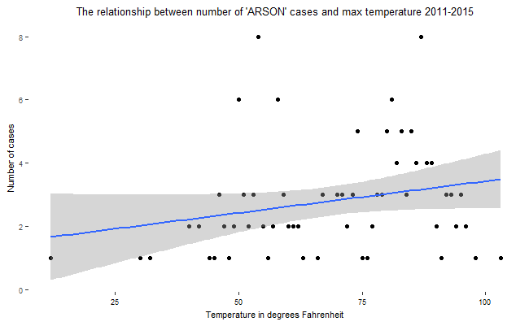

```r
# Part 5: Creating scatterplots
#ARSON
ggplot(maxT_arson,aes(MaxTemp,NumberofCases))+
  geom_point()+
  geom_smooth(method='lm')+
  labs(title = "The relationship between number of 'ARSON' cases and max temperature 2011-2015", x="Temperature in degrees Fahrenheit", y="Number of cases")+
  theme_xkcd+
  theme(plot.title = element_text(hjust = 0.5))
```

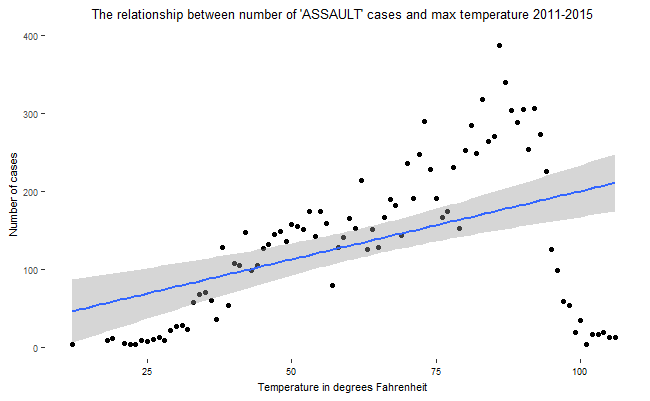

```r
#ASSAULT
ggplot(maxT_assault,aes(MaxTemp,NumberofCases))+
  geom_point()+
  geom_smooth(method='lm')+
  labs(title = "The relationship between number of 'ASSAULT' cases and max temperature 2011-2015", x="Temperature in degrees Fahrenheit", y="Number of cases")+
  theme_xkcd+
  theme(plot.title = element_text(hjust = 0.5))
```

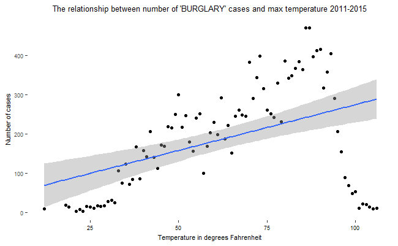

```r
#BURGLARY
ggplot(maxT_burglary,aes(MaxTemp,NumberofCases))+
  geom_point()+
  geom_smooth(method='lm')+
  labs(title = "The relationship between number of 'BURGLARY' cases and max temperature 2011-2015", x="Temperature in degrees Fahrenheit", y="Number of cases")+
  theme_xkcd+
  theme(plot.title = element_text(hjust = 0.5))
```

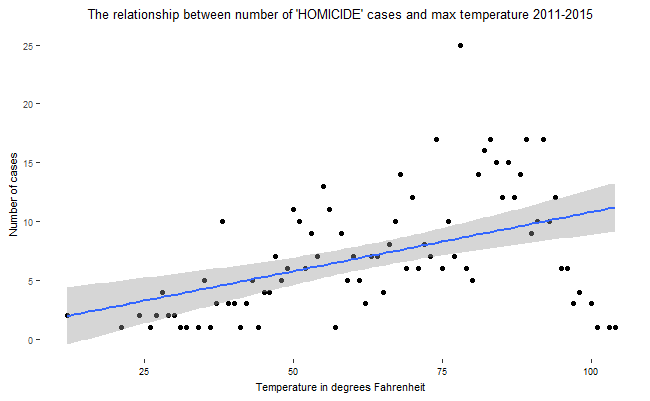

```r
#HOMICIDE
ggplot(maxT_homicide,aes(MaxTemp,NumberofCases))+
  geom_point()+
  geom_smooth(method='lm')+
  labs(title = "The relationship between number of 'HOMICIDE' cases and max temperature 2011-2015", x="Temperature in degrees Fahrenheit", y="Number of cases")+
  theme_xkcd+
  theme(plot.title = element_text(hjust = 0.5))
```

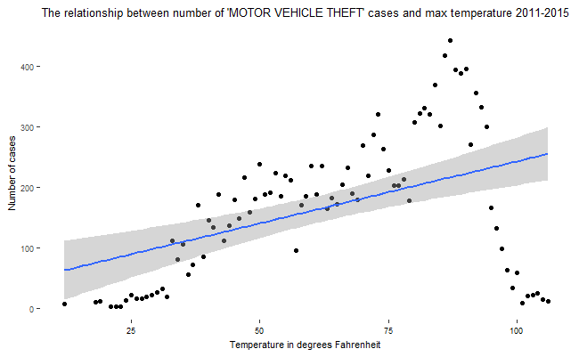

```r
#MOTOR VEHICLE THEFT
ggplot(maxT_mvt,aes(MaxTemp,NumberofCases))+
  geom_point()+
  geom_smooth(method='lm')+
  labs(title = "The relationship between number of 'MOTOR VEHICLE THEFT' cases and max temperature 2011-2015", x="Temperature in degrees Fahrenheit", y="Number of cases")+
  theme_xkcd+
  theme(plot.title = element_text(hjust = 0.5))
```

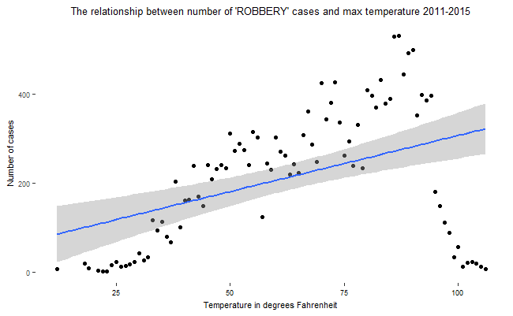

```r
#ROBBERY
ggplot(maxT_robbery,aes(MaxTemp,NumberofCases))+
  geom_point()+
  geom_smooth(method='lm')+
  labs(title = "The relationship between number of 'ROBBERY' cases and max temperature 2011-2015", x="Temperature in degrees Fahrenheit", y="Number of cases")+
  theme_xkcd+
  theme(plot.title = element_text(hjust = 0.5))
```

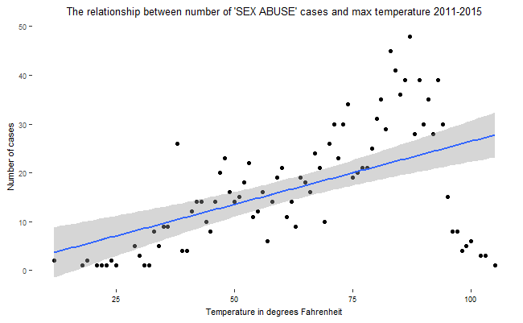

```r
#SEX ABUSE
ggplot(maxT_sa,aes(MaxTemp,NumberofCases))+
  geom_point()+
  geom_smooth(method='lm')+
  labs(title = "The relationship between number of 'SEX ABUSE' cases and max temperature 2011-2015", x="Temperature in degrees Fahrenheit", y="Number of cases")+
  theme_xkcd+
  theme(plot.title = element_text(hjust = 0.5))
```

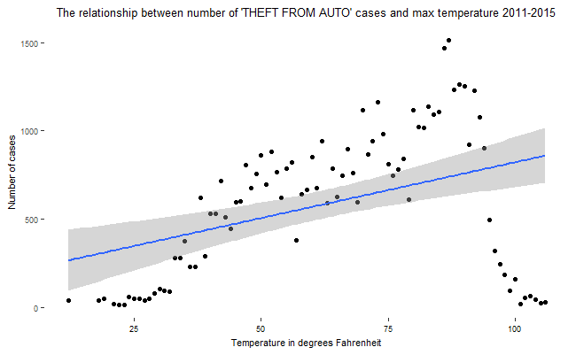

```r
#THEFT FROM AUTO
ggplot(maxT_thefa,aes(MaxTemp,NumberofCases))+
  geom_point()+
  geom_smooth(method='lm')+
  labs(title = "The relationship between number of 'THEFT FROM AUTO' cases and max temperature 2011-2015", x="Temperature in degrees Fahrenheit", y="Number of cases")+
  theme_xkcd+
  theme(plot.title = element_text(hjust = 0.5))
```

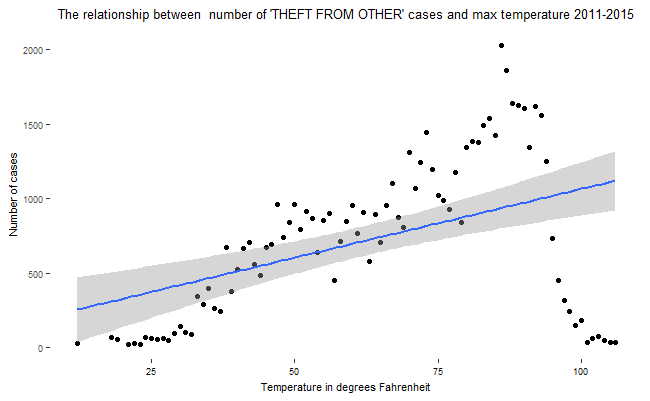

```r
#THEFT FROM OTHER
ggplot(maxT_thefot,aes(MaxTemp,NumberofCases))+
  geom_point()+
  geom_smooth(method='lm')+
  labs(title = "The relationship between  number of 'THEFT FROM OTHER' cases and max temperature 2011-2015", x="Temperature in degrees Fahrenheit", y="Number of cases")+
  theme_xkcd+
  theme(plot.title = element_text(hjust = 0.5))
```

```r
# End of R Script for Research Question [1]
```

Research Question:[2] Is there a relation between the number of nightclubs with the crime rate in a particular geographic unit (cluster)? Description: We are analyzing the crime rate(number of crimes) for each cluster with respect to the number of nightclubs in each cluster. Moreover, we will be looking into different types of crimes (Homicide, Burglary, Sexual Assault, etc.) We will be running the correlation test for each type of crime to figure out if there is a relationship between the number of nightclubs and occurence of crime Datasets: (1) Crime_Incidents_year(2011-2015)- all details about crimes for each year (2) NightClub_Cluster- list of nightclubs classified by cluster id NOTE: The above mentioned datasets are the ones we created after data-cleaning phase. Columns/Attributes used: NEIGHBORHOODCLUSTER, OFFENCE in dataset(1), NEIGHBORHOODCLUSTER, NUMBER_CLUBS in dataset(2) Packages: No extra packages are used

```r
total.cluster.mean
```

```
[1] 4549.974
```

```r
# [Step 3.1] Calculating the maximum and minimum number of crimes occuring in a cluster to figure out the cluster with the highest and lowest number of crimes
#total.cluster.range=range(total.clusterwise$Number.Crimes)
total.cluster.range
```

```
[1]   557 15042
```

```r
# [Step 3.2] Calculating the standard deviation of crimes occuring in a cluster to get an idea about the variance seen in our data
#total.cluster.sd=sd(total.clusterwise$Number.Crimes)
total.cluster.sd
```

```
[1] 3365.461
```

```r
# Crime Type: ARSON
# [Step 1] Creating a subset of those rows which describe crimes of type:ARSON
#arson=subset(merged.dataset,merged.dataset$OFFENSE=="ARSON")
# [Step 2] Creating a frequency table to get the number of crimes for each cluster and writing it to a csv file for recordkeeping
#arson.clusterwise=table(arson$NEIGHBORHOODCLUSTER)
#write.csv(arson.clusterwise,file="arson.clusterwise.csv")
# [Step 3] Reading in the file created in above step and renaming the columns for better understandability
#arson.clusterwise <- read.csv(file.choose())
#names(arson.clusterwise)=c("Cluster","Number.Crimes")
# [Step 4.0] Calculating the average number of crimes occuring in a cluster to be able to understand our data better
arson.cluster.mean=mean(arson.clusterwise$Number.Crimes)
arson.cluster.mean
```

```
[1] 5.571429
```

```r
# [Step 4.1] Calculating the maximum and minimum number of crimes occuring in a cluster to figure out the cluster with the highest and lowest number of crimes
arson.cluster.range=range(arson.clusterwise$Number.Crimes)
arson.cluster.range
```

```
[1]  1 16
```

```r
# [Step 4.2] Calculating the standard deviation of crimes occuring in a cluster to get an idea about the variance seen in our data
arson.cluster.sd=sd(arson.clusterwise$Number.Crimes)
arson.cluster.sd
```

```
[1] 3.676034
```

```r
# Crime Type: ASSAULT W/DANGEROUS WEAPON
# [Step 1] Creating a subset of those rows which describe crimes of type:ASSAULT W/DANGEROUS WEAPON
#assault=subset(merged.dataset,merged.dataset$OFFENSE=="ASSAULT W/DANGEROUS WEAPON")
# [Step 2] Creating a frequency table to get the number of crimes for each cluster and writing it to a csv file for recordkeeping
#assault.clusterwise=table(assault$NEIGHBORHOODCLUSTER)
#write.csv(assault.clusterwise,file="assault.clusterwise.csv")
# [Step 3] Reading in the file created in above step and renaming the columns for better understandability
#assault.clusterwise <- read.csv(file.choose())
#View(assault.clusterwise)
#names(assault.clusterwise)=c("Cluster","Number.Crimes")
# [Step 4.0] Calculating the average number of crimes occuring in a cluster to be able to understand our data better
#assault.cluster.mean=mean(assault.clusterwise$Number.Crimes)
assault.cluster.mean
```

```
[1] 300.4103
```

```r
# [Step 4.1] Calculating the maximum and minimum number of crimes occuring in a cluster to figure out the cluster with the highest and lowest number of crimes
assault.cluster.range=range(assault.clusterwise$Number.Crimes)
assault.cluster.range
```

```
[1]    9 1195
```

```r
# [Step 4.2] Calculating the standard deviation of crimes occuring in a cluster to get an idea about the variance seen in our data
assault.cluster.sd=sd(assault.clusterwise$Number.Crimes)
assault.cluster.sd
```

```
[1] 265.7791
```

```r
# Crime Type: BURGLARY
# [Step 1] Creating a subset of those rows which describe crimes of type:BURGLARY
#burglary=subset(merged.dataset,merged.dataset$OFFENSE=="BURGLARY")
# [Step 2] Creating a frequency table to get the number of crimes for each cluster and writing it to a csv file for recordkeeping
#burglary.clusterwise=table(burglary$NEIGHBORHOODCLUSTER)
#write.csv(burglary.clusterwise,file="burglary.clusterwise.csv")
# [Step 3] Reading in the file created in above step and renaming the columns for better understandability
#burglary.clusterwise <- read.csv(file.choose())
#View(burglary.clusterwise)
names(burglary.clusterwise)=c("Cluster","Number.Crimes")
# [Step 4.0] Calculating the average number of crimes occuring in a cluster to be able to understand our data better
burglary.cluster.mean=mean(burglary.clusterwise$Number.Crimes)
burglary.cluster.mean
```

```
[1] 420
```

```r
# [Step 4.1] Calculating the maximum and minimum number of crimes occuring in a cluster to figure out the cluster with the highest and lowest number of crimes
burglary.cluster.range=range(burglary.clusterwise$Number.Crimes)
burglary.cluster.range
```

```
[1]   45 1317
```

```r
# [Step 4.2] Calculating the standard deviation of crimes occuring in a cluster to get an idea about the variance seen in our data
burglary.cluster.sd=sd(burglary.clusterwise$Number.Crimes)
burglary.cluster.sd
```

```
[1] 306.7907
```

```r
# Crime Type: HOMICIDE
# [Step 1] Creating a subset of those rows which describe crimes of type:HOMICIDE
homicide=subset(merged.dataset,merged.dataset$OFFENSE=="HOMICIDE")
# [Step 2] Creating a frequency table to get the number of crimes for each cluster and writing it to a csv file for recordkeeping
homicide.clusterwise=table(homicide$NEIGHBORHOODCLUSTER)
#write.csv(homicide.clusterwise,file="homicide.clusterwise.csv")
# [Step 3] Reading in the file created in above step and renaming the columns for better understandability
#homicide.clusterwise <- read.csv(file.choose())
#View(homicide.clusterwise)
names(homicide.clusterwise)=c("Cluster","Number.Crimes")
# [Step 4.0] Calculating the average number of crimes occuring in a cluster to be able to understand our data better
#homicide.cluster.mean=mean(homicide.clusterwise$Number.Crimes)
homicide.cluster.mean
```

```
[1] 16.47059
```

```r
# [Step 4.1] Calculating the maximum and minimum number of crimes occuring in a cluster to figure out the cluster with the highest and lowest number of crimes
#homicide.cluster.range=range(homicide.clusterwise$Number.Crimes)
homicide.cluster.range
```

```
[1]  1 46
```

```r
# [Step 4.2] Calculating the standard deviation of crimes occuring in a cluster to get an idea about the variance seen in our data
#homicide.cluster.sd=sd(homicide.clusterwise$Number.Crimes)
homicide.cluster.sd
```

```
[1] 13.09924
```

```r
# Crime Type: MOTOR VEHICLE THEFT
# [Step 1] Creating a subset of those rows which describe crimes of type:MOTOR VEHICLE THEFT
motor.theft=subset(merged.dataset,merged.dataset$OFFENSE=="MOTOR VEHICLE THEFT")
# [Step 2] Creating a frequency table to get the number of crimes for each cluster and writing it to a csv file for recordkeeping
motor.theft.clusterwise=table(motor.theft$NEIGHBORHOODCLUSTER)
#write.csv(motor.theft.clusterwise,file="motor.theft.clusterwise.csv")
# [Step 3] Reading in the file created in above step and renaming the columns for better understandability
#motor.theft.clusterwise <- read.csv(file.choose())
#View(motor.theft.clusterwise)
names(motor.theft.clusterwise)=c("Cluster","Number.Crimes")
# [Step 4.0] Calculating the average number of crimes occuring in a cluster to be able to understand our data better
#motor.theft.cluster.mean=mean(motor.theft.clusterwise$Number.Crimes)
motor.theft.cluster.mean
```

```
[1] 372.3077
```

```r
# [Step 4.1] Calculating the maximum and minimum number of crimes occuring in a cluster to figure out the cluster with the highest and lowest number of crimes
#motor.theft.cluster.range=range(motor.theft.clusterwise$Number.Crimes)
motor.theft.cluster.range
```

```
[1]  39 990
```

```r
# [Step 4.2] Calculating the standard deviation of crimes occuring in a cluster to get an idea about the variance seen in our data
#motor.theft.cluster.sd=sd(motor.theft.clusterwise$Number.Crimes)
motor.theft.cluster.sd
```

```
[1] 258.8394
```

```r
# Crime Type: ROBBERY
# [Step 1] Creating a subset of those rows which describe crimes of type:ROBBERY
robbery=subset(merged.dataset,merged.dataset$OFFENSE=="ROBBERY")
# [Step 2] Creating a frequency table to get the number of crimes for each cluster and writing it to a csv file for recordkeeping
robbery.clusterwise=table(robbery$NEIGHBORHOODCLUSTER)
#write.csv(robbery.clusterwise,file="robbery.clusterwise.csv")
# [Step 3] Reading in the file created in above step and renaming the columns for better understandability
#robbery.clusterwise <- read.csv(file.choose())
#View(robbery.clusterwise)
names(robbery.clusterwise)=c("Cluster","Number.Crimes")
# [Step 4.0] Calculating the average number of crimes occuring in a cluster to be able to understand our data better
#robbery.cluster.mean=mean(robbery.clusterwise$Number.Crimes)
robbery.cluster.mean
```

```
[1] 476.641
```

```r
# [Step 4.1] Calculating the maximum and minimum number of crimes occuring in a cluster to figure out the cluster with the highest and lowest number of crimes
#robbery.cluster.range=range(robbery.clusterwise$Number.Crimes)
robbery.cluster.range
```

```
[1]   15 1792
```

```r
# [Step 4.2] Calculating the standard deviation of crimes occuring in a cluster to get an idea about the variance seen in our data
#robbery.cluster.sd=sd(robbery.clusterwise$Number.Crimes)
robbery.cluster.sd
```

```
[1] 400.9851
```

```r
# Crime Type: SEX ABUSE
# [Step 1] Creating a subset of those rows which describe crimes of type:SEX ABUSE
sex.abuse=subset(merged.dataset,merged.dataset$OFFENSE=="SEX ABUSE")
# [Step 2] Creating a frequency table to get the number of crimes for each cluster and writing it to a csv file for recordkeeping
sex.abuse.clusterwise=table(sex.abuse$NEIGHBORHOODCLUSTER)
#write.csv(sex.abuse.clusterwise,file="sex.abuse.clusterwise.csv")
# [Step 3] Reading in the file created in above step and renaming the columns for better understandability
#sex.abuse.clusterwise <- read.csv(file.choose())
#View(sex.abuse.clusterwise)
names(sex.abuse.clusterwise)=c("Cluster","Number.Crimes")
# [Step 4.0] Calculating the average number of crimes occuring in a cluster to be able to understand our data better
#sex.abuse.cluster.mean=mean(sex.abuse.clusterwise$Number.Crimes)
sex.abuse.cluster.mean
```

```
[1] 35.89474
```

```r
# [Step 4.1] Calculating the maximum and minimum number of crimes occuring in a cluster to figure out the cluster with the highest and lowest number of crimes
#sex.abuse.cluster.range=range(sex.abuse.clusterwise$Number.Crimes)
sex.abuse.cluster.range
```

```
[1]   2 102
```

```r
# [Step 4.2] Calculating the standard deviation of crimes occuring in a cluster to get an idea about the variance seen in our data
#sex.abuse.cluster.sd=sd(sex.abuse.clusterwise$Number.Crimes)
sex.abuse.cluster.sd
```

```
[1] 25.83502
```

```r
# Crime Type: THEFT F/AUTO
# [Step 1] Creating a subset of those rows which describe crimes of type:THEFT F/AUTO
theft.auto=subset(merged.dataset,merged.dataset$OFFENSE=="THEFT F/AUTO")
# [Step 2] Creating a frequency table to get the number of crimes for each cluster and writing it to a csv file for recordkeeping
theft.auto.clusterwise=table(theft.auto$NEIGHBORHOODCLUSTER)
#write.csv(theft.auto.clusterwise,file="theft.auto.clusterwise.csv")
# [Step 3] Reading in the file created in above step and renaming the columns for better understandability
#theft.auto.clusterwise <- read.csv(file.choose())
#View(theft.auto.clusterwise)
names(theft.auto.clusterwise)=c("Cluster","Number.Crimes")
# [Step 4.0] Calculating the average number of crimes occuring in a cluster to be able to understand our data better
#theft.auto.cluster.mean=mean(theft.auto.clusterwise$Number.Crimes)
theft.auto.cluster.mean
```

```
[1] 1316.231
```

```r
# [Step 4.1] Calculating the maximum and minimum number of crimes occuring in a cluster to figure out the cluster with the highest and lowest number of crimes
#theft.auto.cluster.range=range(theft.auto.clusterwise$Number.Crimes)
theft.auto.cluster.range
```

```
[1]   80 5678
```

```r
# [Step 4.2] Calculating the standard deviation of crimes occuring in a cluster to get an idea about the variance seen in our data
#theft.auto.cluster.sd=sd(theft.auto.clusterwise$Number.Crimes)
theft.auto.cluster.sd
```

```
[1] 1174.605
```

```r
# Crime Type: THEFT/OTHER
# [Step 1] Creating a subset of those rows which describe crimes of type:THEFT/OTHER
theft.other=subset(merged.dataset,merged.dataset$OFFENSE=="THEFT/OTHER")
# [Step 2] Creating a frequency table to get the number of crimes for each cluster and writing it to a csv file for recordkeeping
theft.other.clusterwise=table(theft.other$NEIGHBORHOODCLUSTER)
#write.csv(theft.other.clusterwise,file="theft.other.clusterwise.csv")
# [Step 3] Reading in the file created in above step and renaming the columns for better understandability
#theft.other.clusterwise <- read.csv(file.choose())
#View(theft.other.clusterwise)
names(theft.other.clusterwise)=c("Cluster","Number.Crimes")
# [Step 4.0] Calculating the average number of crimes occuring in a cluster to be able to understand our data better
#theft.other.cluster.mean=mean(theft.other.clusterwise$Number.Crimes)
theft.other.cluster.mean
```

```
[1] 1611.051
```

```r
# [Step 4.1] Calculating the maximum and minimum number of crimes occuring in a cluster to figure out the cluster with the highest and lowest number of crimes
#theft.other.cluster.range=range(theft.other.clusterwise$Number.Crimes)
theft.other.cluster.range
```

```
[1]  109 6890
```

```r
# [Step 4.2] Calculating the standard deviation of crimes occuring in a cluster to get an idea about the variance seen in our data
#theft.other.cluster.sd=sd(theft.other.clusterwise$Number.Crimes)
theft.other.cluster.sd
```

```
[1] 1531.008
```

```r
#Clubs
# [Step 0] The relevant dataset is already open (see Step 0.0 at the beginning of the script). Here we rename the columns for better understandability
names(club.clusterwise)=c("Cluster","Number.Clubs")
# [Step 1.0] Calculating the average number of crimes occuring in a cluster to be able to understand our data better
#club.cluster.mean=mean(club.clusterwise$Number.Clubs)
club.cluster.mean
```

[output not shown]

```
[1] 6.857143
```

```r
# [Step 1.1] Calculating the maximum and minimum number of crimes occuring in a cluster to figure out the cluster with the highest and lowest number of crimes
#club.cluster.range=range(club.clusterwise$Number.Clubs)
club.cluster.range
```

```
[1]  1 28
```

```r
# [Step 1.2] Calculating the standard deviation of crimes occuring in a cluster to get an idea about the variance seen in our data
#club.cluster.sd=sd(club.clusterwise$Number.Clubs)
club.cluster.sd
```

```
[1] 8.511143
```

Correlation tests: For figuring out if there is a relationship between the number of nightclubs and number of crimes

```r
# Crime Type: ALL
# [Step 1] Merging the crime dataset with nightclubs dataset
club.total.cluster=merge(club.clusterwise,total.clusterwise,by="Cluster")
# [Step 2] Running the correlation test (linear regression model) between the number of clubs and number of crimes in a cluster
cor.test(club.total.cluster$Number.Clubs,club.total.cluster$Number.Crimes)
```

```
    Pearson's product-moment correlation

data:  club.total.cluster$Number.Clubs and club.total.cluster$Number.Crimes
t = 1.2591, df = 12, p-value = 0.2319
alternative hypothesis: true correlation is not equal to 0
95 percent confidence interval:
 -0.2308143  0.7383552
sample estimates:
      cor
0.3415993
```

```r
# Crime Type: ARSON
# [Step 1] Merging the crime dataset with nightclubs dataset
club.arson.cluster=merge(club.clusterwise,arson.clusterwise,by="Cluster")
# [Step 2] Running the correlation test (linear regression model) between the number of clubs and number of crimes in a cluster
cor.test(club.arson.cluster$Number.Clubs,club.arson.cluster$Number.Crimes)
```

```
    Pearson's product-moment correlation

data:  club.arson.cluster$Number.Clubs and club.arson.cluster$Number.Crimes
t = -1.1228, df = 11, p-value = 0.2854
alternative hypothesis: true correlation is not equal to 0
95 percent confidence interval:
 -0.7407697  0.2797467
sample estimates:
       cor
-0.3206647
```

```r
# Crime Type: ASSAULT W/DANGEROUS WEAPON
# [Step 1] Merging the crime dataset with nightclubs dataset
club.assault.cluster=merge(club.clusterwise,assault.clusterwise,by="Cluster")
# [Step 2] Running the correlation test (linear regression model) between the number of clubs and number of crimes in a cluster
cor.test(club.assault.cluster$Number.Clubs,club.assault.cluster$Number.Crimes)
```

```
    Pearson's product-moment correlation

data:  club.assault.cluster$Number.Clubs and club.assault.cluster$Number.Crimes
t = -0.26221, df = 12, p-value = 0.7976
alternative hypothesis: true correlation is not equal to 0
95 percent confidence interval:
 -0.5827219  0.4740866
sample estimates:
        cor
-0.07547898
```

```r
# Crime Type: BURGLARY
# [Step 1] Merging the crime dataset with nightclubs dataset
club.burglary.cluster=merge(club.clusterwise,burglary.clusterwise,by="Cluster")
# [Step 2] Running the correlation test (linear regression model) between the number of clubs and number of crimes in a cluster
cor.test(club.burglary.cluster$Number.Clubs,club.burglary.cluster$Number.Crimes)
```

```
    Pearson's product-moment correlation

data:  club.burglary.cluster$Number.Clubs and club.burglary.cluster$Number.Crimes
t = -0.88979, df = 12, p-value = 0.3911
alternative hypothesis: true correlation is not equal to 0
95 percent confidence interval:
 -0.6884847  0.3246476
sample estimates:
       cor
-0.2487855
```

```r
# Crime Type: HOMICIDE
# [Step 1] Merging the crime dataset with nightclubs dataset
club.homicide.cluster=merge(club.clusterwise,homicide.clusterwise,by="Cluster")
# [Step 2] Running the correlation test (linear regression model) between the number of clubs and number of crimes in a cluster
cor.test(club.homicide.cluster$Number.Clubs,club.homicide.cluster$Number.Crimes)
```

```
    Pearson's product-moment correlation

data:  club.homicide.cluster$Number.Clubs and club.homicide.cluster$Number.Crimes
t = -1.4964, df = 12, p-value = 0.1604
alternative hypothesis: true correlation is not equal to 0
95 percent confidence interval:
 -0.7659748  0.1697295
sample estimates:
       cor
-0.3965624
```

```r
# Crime Type: MOTOR VEHICLE THEFT
# [Step 1] Merging the crime dataset with nightclubs dataset
club.motor.theft.cluster=merge(club.clusterwise,motor.theft.clusterwise,by="Cluster")
# [Step 2] Running the correlation test (linear regression model) between the number of clubs and number of crimes in a cluster
cor.test(club.motor.theft.cluster$Number.Clubs,club.motor.theft.cluster$Number.Crimes)
```

```
    Pearson's product-moment correlation

data:  club.motor.theft.cluster$Number.Clubs and club.motor.theft.cluster$Number.Crimes
t = -0.56588, df = 12, p-value = 0.5819
alternative hypothesis: true correlation is not equal to 0
95 percent confidence interval:
 -0.6372858  0.4039104
sample estimates:
       cor
-0.1612195
```

```r
# Crime Type: ROBBERY
# [Step 1] Merging the crime dataset with nightclubs dataset
club.robbery.cluster=merge(club.clusterwise,robbery.clusterwise,by="Cluster")
# [Step 2] Running the correlation test (linear regression model) between the number of clubs and number of crimes in a cluster
cor.test(club.robbery.cluster$Number.Clubs,club.robbery.cluster$Number.Crimes)
```

```
    Pearson's product-moment correlation

data:  club.robbery.cluster$Number.Clubs and club.robbery.cluster$Number.Crimes
t = 0.14405, df = 12, p-value = 0.8879
alternative hypothesis: true correlation is not equal to 0
95 percent confidence interval:
 -0.5000548  0.5597874
sample estimates:
       cor
0.04154822
```

```r
# Crime Type: SEX ABUSE
# [Step 1] Merging the crime dataset with nightclubs dataset
club.sex.abuse.cluster=merge(club.clusterwise,sex.abuse.clusterwise,by="Cluster")
# [Step 2] Running the correlation test (linear regression model) between the number of clubs and number of crimes in a cluster
cor.test(club.sex.abuse.cluster$Number.Clubs,club.sex.abuse.cluster$Number.Crimes)
```

```
    Pearson's product-moment correlation

data:  club.sex.abuse.cluster$Number.Clubs and club.sex.abuse.cluster$Number.Crimes
t = 0.40588, df = 12, p-value = 0.692
alternative hypothesis: true correlation is not equal to 0
95 percent confidence interval:
 -0.4414660  0.6093285
sample estimates:
      cor
0.1163716
```

```r
# Crime Type: THEFT F/AUTO
# [Step 1] Merging the crime dataset with nightclubs dataset
club.theft.auto.cluster=merge(club.clusterwise,theft.auto.clusterwise,by="Cluster")
# [Step 2] Running the correlation test (linear regression model) between the number of clubs and number of crimes in a cluster
cor.test(club.theft.auto.cluster$Number.Clubs,club.theft.auto.cluster$Number.Crimes)
```

```
    Pearson's product-moment correlation

data:  club.theft.auto.cluster$Number.Clubs and club.theft.auto.cluster$Number.Crimes
t = 0.82932, df = 12, p-value = 0.4231
alternative hypothesis: true correlation is not equal to 0
95 percent confidence interval:
 -0.3397219  0.6794677
sample estimates:
     cor
0.232824
```

```r
# Crime Type: THEFT/OTHER
# [Step 1] Merging the crime dataset with nightclubs dataset
club.theft.other.cluster=merge(club.clusterwise,theft.other.clusterwise,by="Cluster")
# [Step 2] Running the correlation test (linear regression model) between the number of clubs and number of crimes in a cluster
cor.test(club.theft.other.cluster$Number.Clubs,club.theft.other.cluster$Number.Crimes)
```

```
    Pearson's product-moment correlation

data:  club.theft.other.cluster$Number.Clubs and club.theft.other.cluster$Number.Crimes
t = 2.4881, df = 12, p-value = 0.02853
alternative hypothesis: true correlation is not equal to 0
95 percent confidence interval:
 0.07646302 0.85065428
sample estimates:
      cor
0.5833752
```